# 小地域数が変更した場合の人口変化の可視化

鹿児島市の例

[岩田真一郎](https://shinichiro-iwata.github.io/)（[神奈川大学経済学部](https://www.econ.kanagawa-u.ac.jp/)）

2022-07-14作成，2022-07-14改定

# 目的

[小地域統計による人口変化の可視化](https://shinichiro-iwata.github.io/geospatial-data-visualization/cbd1-visualization.html)同様に2年分のデータを用いて国勢調査の小地域（町丁・字等別，ポリゴン）に人口変化及び人口変化率を示す．ただし，今回は例えば小地域の境界線の変更によって，小地域の数（形状）が変更した場合（鹿児島市）を取り扱う．

- 時間の経過とともに小地域数が変更することを考慮すると，時系列分析ではメッシュ統計のほうが取り扱いやすい．
  - ただし，[地図で見る統計](https://www.e-stat.go.jp/gis)は小地域統計がメッシュ統計より充実している．

ライブラリ：`sf`，`tidyverse`，`scales`

```r
library(sf)
library(tidyverse)

#muted()利用
library(scales)
```

# 小地域の人口の可視化

**境界データのダウンロード**

- [地図で見る統計](https://www.e-stat.go.jp/gis) > 境界データダウンロード > 小地域 > 国勢調査 > 2020年（または2010年） > 小地域（町丁・字等別）（JGD2000） > 世界測地系緯度経度・Shapefile > 46201 鹿児島市

```r
#2020年
Kagoshima_shi_map20<-
  read_sf("A002005212020DDSWC46201/r2ka46201.shp")

#2010年
Kagoshima_shi_map10<-
  read_sf("A002005212010DDSWC46201/h22ka46201.shp")
```

**一般調査区の抽出**

水面調査区（海上ポリゴン）が目立つため，一般調査区のみ抽出（`filiter()`）．

```r
Kagoshima_shi_map20 %>%
  filter(HCODE==8101) ->
  Kagoshima_shi_map20

Kagoshima_shi_map10 %>%
  filter(HCODE==8101) ->
  Kagoshima_shi_map10
```

**データ結合の準備**

後ほど，`KEY_CODE`列を用いて境界データと統計データを結合する．ただし，境界データは`KEY_CODE`が文字データ型，統計データは数値データ型のため結合できない．

- ここでは，境界データは`KEY_CODE`を数値データ型（`as.numeric()`）に変更．

```r
#KEY_CODEを数値データ型に
Kagoshima_shi_map20 %>%
  mutate(KEY_CODE=as.numeric(KEY_CODE)) ->
  Kagoshima_shi_map20

Kagoshima_shi_map10 %>%
  mutate(KEY_CODE=as.numeric(KEY_CODE)) ->
  Kagoshima_shi_map10
```

**統計データのダウンロード**

- [地図で見る統計](https://www.e-stat.go.jp/gis) > 統計データダウンロード > 小地域 > 国勢調査 > 2020年（または2010年） > 小地域（町丁・字等別） > 男女別人口総数及び世帯総数 > 46鹿児島県
  - データはテキスト形式．`read.table`で読込．
    - `Kogoshima_pop#`と名付ける．
    - `header=TRUE`は列名が含まれていることを意味する．仮に列名がなければ`FALSE`．ダウンロードしたデータは2列にわたって列名がある．
    - `sep=","`はデータがカンマで区切られていることを意味する．`skip=1`は1番最初の行を削除することを意味する．後ほど，1行目にあった情報（`KEY_CODE`，`CITYNAME`）を再度加える．
    - **文字化け**問題：文字コードの関係で，テキストファイルが適切に読み込めない場合がある（不正なマルチバイト文字 ．．．）．この場合は、`fileEncoding="CP932"`のオプションを加える（例えば`skip=1`の後に）．ここでは，加えておく．
    - その他、文字化け問題については[Rのエンコーディング問題](https://shohei-doi.github.io/quant_polisci/encoding-r.html)を参照．

```r
#2020年（文字化け防止のため，オプションを加えておく）
Kagoshima_pop20<-
  read.table("tblT001081C46/tblT001081C46.txt",
                  header=TRUE, sep=",", skip=1,
                  fileEncoding="CP932")

#列名の変更（1，3列目）
Kagoshima_pop20 %>%
  rename("KEY_CODE"=X, "CITYNAME"=X.2) ->
  Kagoshima_pop20

#2010年
Kagoshima_pop10<-
  read.table("tblT000572C46/tblT000572C46.txt",
             header=TRUE, sep=",", skip=1,
             fileEncoding="CP932")

#列名の変更（1，3列目）
Kagoshima_pop10 %>%
  rename("KEY_CODE"=X, "CITYNAME"=X.2) ->
  Kagoshima_pop10
```

- 鹿児島市だけを取り扱うため，鹿児島市の人口総数だけを抜き出す（`filiter`）．`Kagoshima_shi_pop#`と名付ける．

```r
Kagoshima_pop20 %>%
  filter(CITYNAME=="鹿児島市") ->
  Kagoshima_shi_pop20

Kagoshima_pop10 %>%
  filter(CITYNAME=="鹿児島市") ->
  Kagoshima_shi_pop10
```

**人口総数**

小地域の人口は「人口総数」の列に含まれているが，文字データ型情報．

- 数値データ型（`numeric`）情報に変更（`mutate`）する．再び `Kagoshima_shi_pop_#`と名付ける．
  - 欠損値（データに「-」含まれる）は`NA`に強制変換（`Warning message`（警告メッセージ）が出現するが問題ない）．

```r
Kagoshima_shi_pop20 %>%
  mutate(人口総数=as.numeric(人口総数)) ->
  Kagoshima_shi_pop20

Kagoshima_shi_pop10 %>%
  mutate(人口総数=as.numeric(人口総数)) ->
  Kagoshima_shi_pop10
```

**データ結合1**

各年の境界データと統計データを結合．`Kagoshima_shi#`と名付ける．

```r
Kagoshima_shi10<-
  left_join(Kagoshima_shi_map10, Kagoshima_shi_pop10,
            by=c("KEY_CODE"))

Kagoshima_shi20<-
  left_join(Kagoshima_shi_map20, Kagoshima_shi_pop20,
            by=c("KEY_CODE"))
```

**可視化**

各年の人口総数を可視化．

- **注意**：小地域が変更．
  - 例として2010年以降に住所が設置・編入された広木を黄色い枠で示す．
  - 広木は1丁目，2丁目，3丁目の3つのポリゴンで構成．これを`summarise()`で1つのポリゴンにする．
- 2010年と2020年の地図を2枚横に並べる（`ncol=2`）．そのためにライブラリ`patchwork`を呼び出す．

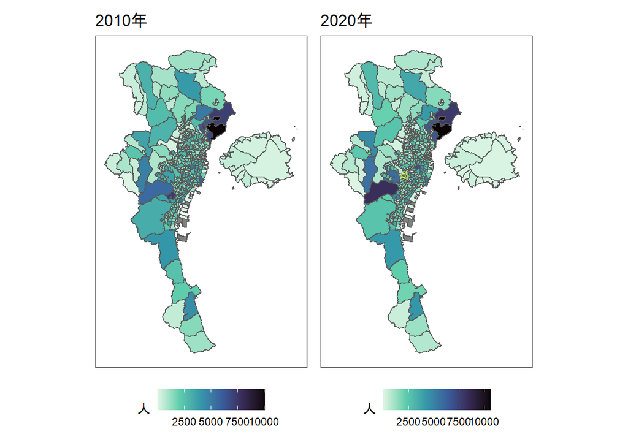

```r
#広木の選別
Kagoshima_shi20 %>%
  filter(KEYCODE1>="201329001" & KEYCODE1<="201329003") %>%
  summarise() ->
  Hiroki

#2010年の人口（fig1）
fig1<-
  ggplot()+
  geom_sf(data=Kagoshima_shi10, aes(fill=人口総数))+
  scale_fill_viridis_c(option="G", direction=-1)+
  labs(fill="人")+
  ggtitle("2010年")+
  coord_sf(datum=NA)+
  theme_bw()+
  theme(legend.position="bottom")

#2020年の人口（fig2），黄色い枠が「広木」
fig2<-
  ggplot()+
  geom_sf(data=Kagoshima_shi20, aes(fill=人口総数))+
  scale_fill_viridis_c(option="G", direction=-1)+
  geom_sf(data=Hiroki, fill="NA", color="yellow", size=0.35)+
  labs(fill="人")+
  ggtitle("2020年")+
  coord_sf(datum=NA)+
  theme_bw()+
  theme(legend.position="bottom")

#図を並べるため
library(patchwork)

#図を並べる
fig1+fig2+
  plot_layout(ncol=2)
```

# 人口変化の可視化

**データ結合2**

[小地域統計による人口変化の可視化](https://shinichiro-iwata.github.io/geospatial-data-visualization/cbd1-visualization.html)で例とした小田原市の場合，2010年から2020年の間に（おそらく）小地域の数に変更なし．このため，2010年と2020年の国勢調査の行数（←小地域の数）が揃い，`cbind()`でデータを横方向に結合でき，人口変化が計算可能に．

- `cbind()`は行数が揃っている必要がある．
- しかし，今回は小地域の数（形状）が異なる．統計データは，2010年には410行，2020年は402行と小地域の数にずれが生じている．このため，`cbind()`を試すとエラーが生じる．
  - そこで，`sf`クラスのデータ（データフレーム）を結合する`st_join()`を試し，この問題を解決する．結合したデータは`Kagoshima_shi1020`と名付ける．
  - 左のデータの列名が「列名.x」，右のデータの列名が「列名.y」になる．
  - 以下，よりスマートなコードがあるかもしれない．
- 結合したデータの行数を`nrow()`で調べる．
  - 行数が`2257`行と返ってくる．かなり行数が増えているが，これは単純に横方向に2つのデータを結合していないことを意味する．

```r
Kagoshima_shi1020<-
  st_join(Kagoshima_shi10, Kagoshima_shi20)

nrow(Kagoshima_shi1020)
```

```
## [1] 2257
```

**データクリーニング**

可能な限り，同一の小地域の人口変化を調べたい．

- そこで，同一の小地域を抜き出す．
  - 調べてみると，`KEY_CODE`が2010年と2020年で異なる地域もあるため，ここでは小地域を識別する列の一つである`KEYCODE1`を利用．
  - `KEYCODE1`は文字型データのため数値型データに変更．
  - 同一小地域の場合，2010年と2020年で`KEYCODE1`は同じはず．そこで，2020年の`KEYCODE1`（`KEYCODE1.y`）から2010年の`KEYCODE1`（`KEYCODE1.x`）を差し引き（差を`d`とする），その値（`d`）が`0`になるデータだけを抜き出す．
  - `nrow()`で調べる．行数が`374`行と返ってくる．この過程でいくつかの小地域が落ちた可能性がある．

```r
#数値型データに変更
Kagoshima_shi1020 %>%
  mutate(KEYCODE1.x=as.numeric(KEYCODE1.x),
         KEYCODE1.y=as.numeric(KEYCODE1.y)) ->
  Kagoshima_shi1020

#識別番号の差
Kagoshima_shi1020 %>%
  mutate(d=KEYCODE1.y-KEYCODE1.x) ->
  Kagoshima_shi1020

#識別番号が等しい小地域だけ選別
Kagoshima_shi1020 %>%
  filter(d=="0") ->
  Kagoshima_shi1020

nrow(Kagoshima_shi1020)
```

```
## [1] 374
```

**人口変化**

- 2020年の人口総数（人口総数.y）から2010年の人口総数（人口総数.x）を引き，人口変化をとらえる．計算された列を`diff_pop`と名付ける．

```r
#人口変化
Kagoshima_shi1020 %>%
  mutate(diff_pop=人口総数.y-人口総数.x) ->
  Kagoshima_shi1020
```

**完成図**

完成図の可視化．

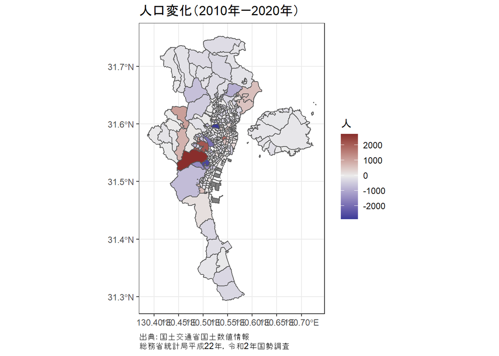

```r
#人口変化の可視化
ggplot()+
  geom_sf(data=Kagoshima_shi1020, aes(fill=diff_pop))+
  scale_fill_gradient2(low=muted("blue"),
                       mid="gray92",
                       high=muted("red"))+
  labs(fill="人",
  caption="出典：国土交通省国土数値情報
総務省統計局平成22年，令和2年国勢調査")+
  ggtitle("人口変化（2010年ー2020年）")+
  theme_bw()+
  theme(plot.caption=element_text(hjust=0))
```

**Rによる地理空間データの可視化**

- チュートリアル[ホーム](https://shinichiro-iwata.github.io/geospatial-data-visualization/)